# rct_assignment

Chuyuan Zhong

2023-03-24

```r
library(ggplot2)
library(tidyverse)
library(miceadds)
library(lmtest)
library(multiwayvcov)
library(AER)
```

```r
school = read.csv('rct_problem_set.csv')
head(school)
```

```
##   school_id grade treatcluster treatcluster_group person_id age female
## 1         1     1            1                  3      7021   5      0
## 2         1     2            1                  4       296   7      1
## 3         1     3            1                  5      3559   8      1
## 4         1     4            0                  0       908  10      1
## 5         1     5            1                  1     14713   9      0
## 6         2     1            1                  4      1657   7      1
##   treatment attend math read
## 1         0      1  471  604
## 2         1      1  721  766
## 3         1      1  658  749
## 4         0      1  576  473
## 5         0      1  563  574
## 6         1      1  723  742
```

```r
dim(school)
```

```
## [1] 817287     11
```

1. Start by regressing the outcome of interest, attend, on the treatment indicator. What are your preliminary results? How does accounting for the clustered randomization design affect your preliminary results?

```r
nonclustered=lm(attend ~ treatment, data = school)
school$clusters <- paste(school$school_id,"-",school$grade)
clustered = lm.cluster(attend ~ treatment, data = school, cluster = "clusters")
summary(nonclustered)
```

```
##
## Call:
## lm(formula = attend ~ treatment, data = school)
##
## Residuals:
##      Min       1Q   Median       3Q      Max
## -0.99035  0.00965  0.06393  0.06393  0.06393
##
## Coefficients:
##              Estimate Std. Error t value Pr(>|t|)
## (Intercept) 0.9360750  0.0002993  3128.0   <2e-16 ***
## treatment   0.0542734  0.0005555    97.7   <2e-16 ***
## ---
## Signif. codes:  0 '***' 0.001 '**' 0.01 '*' 0.05 '.' 0.1 ' ' 1
##
## Residual standard error: 0.2127 on 711813 degrees of freedom
##   (105472 observations deleted due to missingness)
## Multiple R-squared:  0.01323,    Adjusted R-squared:  0.01323
## F-statistic:  9546 on 1 and 711813 DF,  p-value: < 2.2e-16
```

```r
summary(clustered)
```

```
## R^2= 0.01323
##
##               Estimate   Std. Error   t value Pr(>|t|)
## (Intercept) 0.93607499 0.0004032584 2321.2783        0
## treatment   0.05427341 0.0004557675  119.0813        0
```

Based on the preliminary results, p-values less than 0.05 that suggests that there is a statistically significant. We can conclude that free lunches randomly provided to selected elementary school students increases the school attendance.

2. Check for balance between the treatment and control observations based on age, gender, math scores and reading scores. Are these observables balanced across the treatment and control groups?

```r
m_age = lm.cluster(age~treatment, data = school, cluster="clusters")
m_female = lm.cluster(female~treatment, data = school, cluster="clusters")
m_math = lm.cluster(math~ treatment, data = school, cluster="clusters")
m_read = lm.cluster(read~treatment, data = school, cluster="clusters")
check = lm.cluster(treatment~ age + female + math + read, data = school, cluster="clusters")
summary(m_age)
```

```
## R^2= 0
##
##                Estimate Std. Error      t value  Pr(>|t|)
## (Intercept) 7.999596543 0.02834202 282.25219610 0.0000000
## treatment   0.003163687 0.04341158   0.07287658 0.9419043
```

```r
summary(m_female)
```

```
## R^2= 0
##
##                Estimate   Std. Error    t value   Pr(>|t|)
## (Intercept)  0.57151355 0.0006688208 854.509285 0.00000000
## treatment   -0.00214326 0.0012164420  -1.761909 0.07808462
```

```r
summary(m_math)
```

```
## R^2= 0
##
##                Estimate Std. Error      t value Pr(>|t|)
## (Intercept) 657.1714294  0.1194312 5502.5100667 0.000000
## treatment     0.1287531  0.2197723    0.5858475 0.557978
```

```r
summary(m_read)
```

```
## R^2= 0
##
##                Estimate Std. Error      t value  Pr(>|t|)
## (Intercept) 604.4447454  0.1500886 4027.2528425 0.0000000
## treatment     0.1256152  0.2925068    0.4294437 0.6676004
```

```r
summary(check)
```

```
## R^2= 1e-05
##
##                  Estimate   Std. Error     t value     Pr(>|t|)
## (Intercept)  2.837135e-01 3.674777e-02  7.72056473 1.158154e-14
## age          3.276313e-04 4.475717e-03  0.07320198 9.416454e-01
## female      -2.328857e-03 1.117858e-03 -2.08332089 3.722198e-02
## math         7.899799e-06 5.916617e-06  1.33518860 1.818146e-01
## read         2.524821e-07 4.488207e-06  0.05625455 9.551390e-01
```

We can further test in by running a f test

```r
f = linearHypothesis(check, c("age", "female", "math", "read"), test="F")
```

```
## residual df unavailable, test set to 'Chisq'
```

```r
f
```

```
## Linear hypothesis test
##
## Hypothesis:
## age = 0
## female = 0
## math = 0
## read = 0
##
## Model 1: restricted model
## Model 2: check
##
##   Df  Chisq Pr(>Chisq)
## 1
## 2  4 4.8142     0.3069
```

3. Check if there are observations that are missing outcome data. If there are any, does this attrition appear random or not?

```r
sum(is.na(school$attend))
```

```
## [1] 105472
```

```r
school$a = ifelse(is.na(school$attend), 1, 0)
checkattrition = lm(a ~ treatment, data = school)
summary(checkattrition)
```

```
##
## Call:
## lm(formula = a ~ treatment, data = school)
##
## Residuals:
##     Min      1Q  Median      3Q     Max
## -0.1294 -0.1294 -0.1289 -0.1289  0.8711
##
## Coefficients:
##              Estimate Std. Error t value Pr(>|t|)
## (Intercept) 0.1289182  0.0004402 292.850   <2e-16 ***
## treatment   0.0004587  0.0008170   0.561    0.575
## ---
## Signif. codes:  0 '***' 0.001 '**' 0.01 '*' 0.05 '.' 0.1 ' ' 1
##
## Residual standard error: 0.3353 on 817285 degrees of freedom
## Multiple R-squared:  3.857e-07,  Adjusted R-squared:  -8.379e-07
## F-statistic: 0.3152 on 1 and 817285 DF,  p-value: 0.5745
```

There are 105472 missing outcome data. Since the p value is larger than 0.05, the attrition appear random.

4. Implement a permutation test to assess the credibility of your estimated treatment effect. Include a plot of the distribution of estimates from your permutation samples and mark your estimate based on the actual data in this distribution. What fraction of estimates from your permutation test have higher estimated treatment effects that the estimate based on the actual data?

```r
school <- na.omit(school)
treatment <- school$treatment
outcome <- school$attend
original<-mean(outcome[treatment==1])-mean(outcome[treatment==0])
```

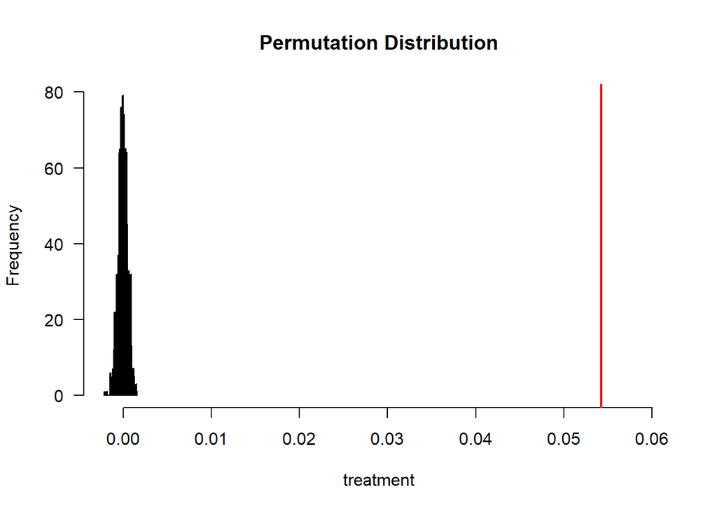

```r
# https://towardsdatascience.com/permutation-test-in-r-77d551a9f891
permutation.test <- function(treatment, outcome, n){
  distribution=c()
  result=0
  for(i in 1:n){
    distribution[i]=diff(by(outcome, sample(treatment, length(treatment), FALSE), mean))
  }
  result=sum(abs(distribution) >= abs(original))/(n)
  return(list(result, distribution))
}

test1 <- permutation.test(treatment, outcome, 1000)
hist(test1[[2]], breaks=50, col='blue', main="Permutation Distribution", las=1, xlab='treatment', border = "black", xlim=c(-0.002, 0.06))
abline(v=original, lwd=2, col="red")
```

Based on the distribution, we can see that the estimated treatment effects are less than the estimates from the actual data.

```r
p_value <- test1[[1]]
p_value
```

```
## [1] 0
```

Since the P value is 0, there is strong evidence to against the null hypothesis,this means there are difference between treatment group and control group.Therefore, there is no fraction of estimates from the permutation test have higher estimated treatment effects that the estimate based on the actual data.

We can further test it using t-test.

```r
t.test(outcome~treatment)
```

```
##
##  Welch Two Sample t-test
##
## data:  outcome by treatment
## t = -133.73, df = 711512, p-value < 2.2e-16
## alternative hypothesis: true difference in means between group 0 and group 1 is not equal to 0
## 95 percent confidence interval:
##  -0.05506885 -0.05347798
## sample estimates:
## mean in group 0 mean in group 1
##       0.9360750       0.9903484
```

Since P value is less than 0.05, there is a statistically significant and suggests that there is difference in means between treatment=1 and treatment=0. With treatment intervention, the sample estimates for the mean is 0.9903484, without treatment, the sample estimates for the mean is 0.9360750.

5. Now suppose that you learn that, in addition to being clustered at the school and grade level, you learn that the randomization varied treatment intensity within treatment clusters. The treatcluster variable captures which school-grades were assigned to treatment and which were assigned to control. Within the treated clusters, the clusters were randomly assigned to groups 1, 2, 3, 4 and 5, with the fraction of observations within these clusters assigned to treatment varying from 20%, 40%, 60%, 80% and 100% respectively.
1. To test for peer effects from the treatment, create two sets of indicator variables: (1) indicator variables for treatment observations within each treated cluster group and (2) indicator variables for observations within each treated cluster group. Regress the attend outcome variable on these indicators.

```r
school <- school %>%
    mutate(treat_within_group = if_else(treatcluster_group != 0 & treatment == 1, 1, 0)) %>%
    mutate(all_within_group = if_else(treatcluster_group != 0, 1, 0))

model_intensity <- lm(attend ~ treat_within_group + all_within_group, data = school)

summary(model_intensity)
```

```
##
## Call:
## lm(formula = attend ~ treat_within_group + all_within_group,
##     data = school)
##
## Residuals:
##      Min       1Q   Median       3Q      Max
## -0.99035  0.00965  0.04827  0.06987  0.06987
##
## Coefficients:
##                     Estimate Std. Error t value Pr(>|t|)
## (Intercept)        0.9301302  0.0003513 2648.02   <2e-16 ***
## treat_within_group 0.0386165  0.0007373   52.38   <2e-16 ***
## all_within_group   0.0216017  0.0006696   32.26   <2e-16 ***
## ---
## Signif. codes:  0 '***' 0.001 '**' 0.01 '*' 0.05 '.' 0.1 ' ' 1
##
## Residual standard error: 0.2126 on 711812 degrees of freedom
## Multiple R-squared:  0.01467,    Adjusted R-squared:  0.01467
## F-statistic:  5301 on 2 and 711812 DF,  p-value: < 2.2e-16
```

```r
school1 <- school %>%
  mutate(treat_group1 = if_else(treatcluster_group == 1 & treatment == 1, 1, 0)) %>%
  mutate(treat_group2 = if_else(treatcluster_group == 2 & treatment == 1, 1, 0)) %>%
  mutate(treat_group3 = if_else(treatcluster_group == 3 & treatment == 1, 1, 0)) %>%
  mutate(treat_group4 = if_else(treatcluster_group == 4 & treatment == 1, 1, 0)) %>%
  mutate(treat_group5 = if_else(treatcluster_group == 5 & treatment == 1, 1, 0)) %>%
  mutate(group1 = if_else(treatcluster_group == 1 & treatment == 0, 1, 0)) %>%
  mutate(group2 = if_else(treatcluster_group == 2 & treatment == 0, 1, 0)) %>%
  mutate(group3 = if_else(treatcluster_group == 3 & treatment == 0, 1, 0)) %>%
  mutate(group4 = if_else(treatcluster_group == 4 & treatment == 0, 1, 0)) %>%
  mutate(group5 = if_else(treatcluster_group == 5 & treatment == 0, 1, 0))

model_1 <-lm(attend ~ treat_group1 + treat_group2 + treat_group3 + treat_group4 + treat_group5 + group1 + group2 +group3 +group4 +group5, data = school1)
summary(model_1)
```

```
##
## Call:
## lm(formula = attend ~ treat_group1 + treat_group2 + treat_group3 +
##     treat_group4 + treat_group5 + group1 + group2 + group3 +
##     group4 + group5, data = school1)
##
## Residuals:
##      Min       1Q   Median       3Q      Max
## -0.99092  0.00981  0.05823  0.06987  0.06987
##
## Coefficients: (1 not defined because of singularities)
##               Estimate Std. Error t value Pr(>|t|)
## (Intercept)  0.9301302  0.0003512 2648.55   <2e-16 ***
## treat_group1 0.0597021  0.0018642   32.03   <2e-16 ***
## treat_group2 0.0607948  0.0013301   45.71   <2e-16 ***
## treat_group3 0.0604073  0.0010548   57.27   <2e-16 ***
## treat_group4 0.0600579  0.0009358   64.18   <2e-16 ***
## treat_group5 0.0600870  0.0009359   64.20   <2e-16 ***
## group1       0.0116428  0.0009905   11.76   <2e-16 ***
## group2       0.0207541  0.0011027   18.82   <2e-16 ***
## group3       0.0307801  0.0012725   24.19   <2e-16 ***
## group4       0.0406005  0.0017782   22.83   <2e-16 ***
## group5              NA         NA      NA       NA
## ---
## Signif. codes:  0 '***' 0.001 '**' 0.01 '*' 0.05 '.' 0.1 ' ' 1
##
## Residual standard error: 0.2125 on 711805 degrees of freedom
## Multiple R-squared:  0.01508,    Adjusted R-squared:  0.01507
## F-statistic:  1211 on 9 and 711805 DF,  p-value: < 2.2e-16
```

2. Plot the coefficients on the direct treatment effects (y-axis) against the fraction treated (x-axis). How do the direct treatment effects vary with the fraction treated?

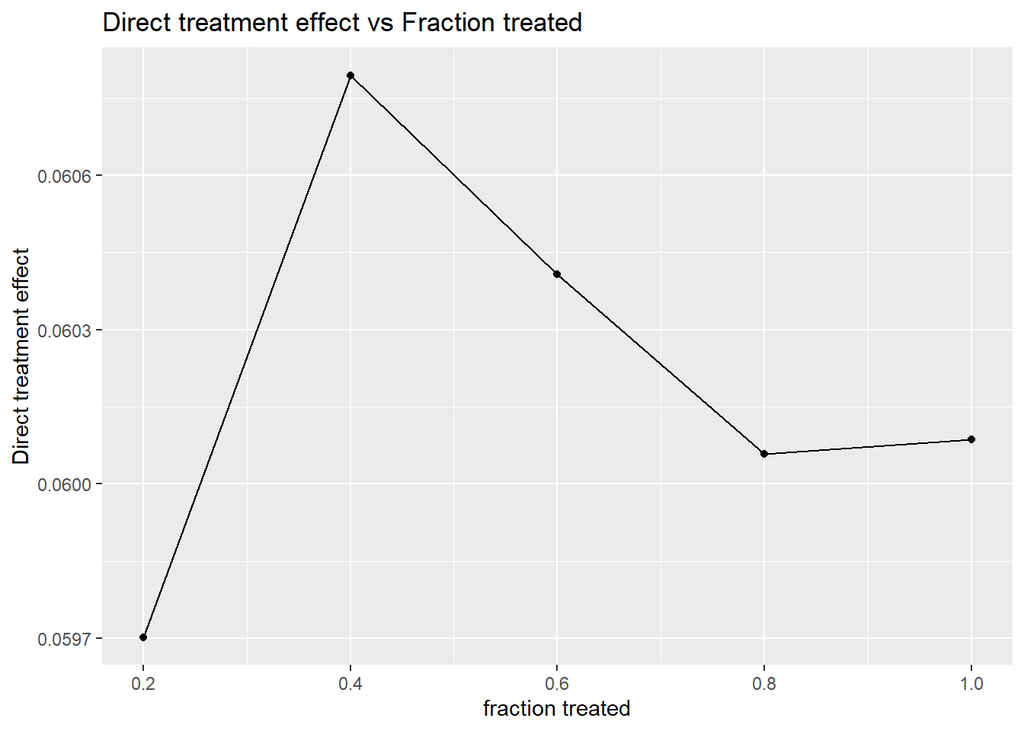

```r
direct_coeff = coef(model_1)

treatment_intensity <- data.frame(treat_frac = c(0.2, 0.4, 0.6, 0.8, 1),
                                  direct_coeff = direct_coeff[2:6])
ggplot(treatment_intensity, aes(x = treat_frac, y = direct_coeff)) +
  geom_point() +
  geom_line() +
  labs(title = "Direct treatment effect vs Fraction treated", x = "fraction treated", y="Direct treatment effect")
```

When the treatment fraction is 40%, direct effect reaches the biggest. Overall, there is no significant difference in direct effects across all treatment groups.

3. Plot the coefficients on the indirect treatment effects (y-axis) against the fraction treated (x-axis). How do the indirect treatment effects vary with the fraction treated? Overall, what do you conclude about possible peer effects or spillovers from the treatment?

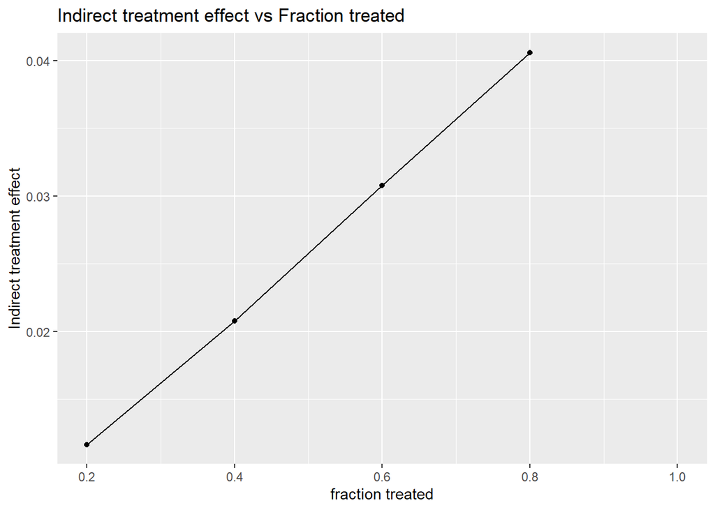

```r
indirect_coeff = coef(model_1)

treatment_intensity <- data.frame(treat_frac = c(0.2, 0.4, 0.6, 0.8, 1),
                                  indirect_coeff = indirect_coeff[7:11])

ggplot(treatment_intensity, aes(x = treat_frac, y = indirect_coeff)) +
  geom_point() +
  geom_line() +
  labs(title = "Indirect treatment effect vs Fraction treated", x = "fraction treated", y="Indirect treatment effect")
```

The indirect effect and the proportion of treated students in groups are positively related. This means that indirect effects increase as more treated students are present in the groups. The effect increases from about 1% to 4% as the proportion of treated students increases from 20% to 80%. This suggests that providing free lunches to selected elementary school students at random increases school attendance. It also suggests that student behavior influences each other and that the attendance of treated students may have influenced the attendance of untreated students, leading to an overall increase in attendance.